# Optimization_HW3_ADSmaniotto

### Optimization Homework 3

#### Kenwan Cheung, Chantel Miller, Joan Lee, Tony Smaniotto

##### Question 1

```julia
using JuMP
using GLPKMathProgInterface

myModel = Model(solver=GLPKSolverLP())
@variable(myModel, x1 >= 0)
@variable(myModel, x2 >= 0)
@constraint(myModel, -x1 + x2 <= 0)
@constraint(myModel, -x1 + 2*x2 <= 2)
@constraint(myModel, x2 <= 3)
@constraint(myModel, x1 >= 1)
@objective(myModel, Min, 3*x1 + -4*x2)
myModel
```

$$ \begin{alignat*}{1}\min\quad & 3 x1 - 4 x2\\ \text{Subject to} \quad & -x1 + x2 \leq 0\\ & -x1 + 2 x2 \leq 2\\ & x2 \leq 3\\ & x1 \geq 1\\ & x1 \geq 0\\ & x2 \geq 0\\ \end{alignat*} $$

```julia
@time begin
    status = solve(myModel)
end
println("Objective value: ", getobjectivevalue(myModel))
println("x1 = ", getvalue(x1))
println("x2 = ", getvalue(x2))
```

```
  0.005801 seconds (79 allocations: 5.375 KiB)
Objective value: -2.0
x1 = 2.0
x2 = 2.0
```

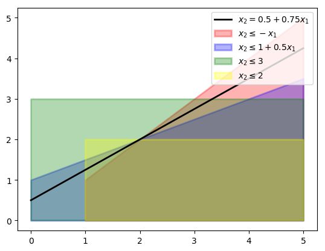

```
PyObject <matplotlib.legend.Legend object at 0x13fa36110>
```

```julia
x1 = collect(0:0.1:5)
#x2a = x1
x2a = ifelse.(x1.>=1, x1, NaN)
x2b = ifelse.(1 + 1/2*x1.>=0, 1+1/2*x1, NaN)
x2c = ifelse.(x1.>=0, 3, NaN)
x2d = ifelse.(x1.>= 1, 2, NaN)
x2e = ifelse.(1/2+3/4*x1.>=0, 0.5+0.75x1, NaN)

fig, ax = subplots()
ax[:fill_between](x1,x2a,color="red",linewidth=2,label=L"x_{2} \leq -x_{1}",alpha=0.3)
ax[:legend](loc="upper right")
ax[:fill_between](x1,x2b,color="blue",linewidth=2,label=L"x_{2} \leq 1 + 0.5x_{1}",alpha=0.3)
ax[:legend](loc="upper right")
ax[:fill_between](x1,x2c,color="green",linewidth=2,label=L"x_{2} \leq 3",alpha=0.3)
ax[:legend](loc="upper right")
ax[:fill_between](x1,x2d,color="yellow",linewidth=2,label=L"x_{2} \leq 2",alpha=0.3)
ax[:legend](loc="upper right")
ax[:plot](x1,x2e,color="black",linewidth=2,label=L"x_{2} = 0.5 + 0.75x_{1}",alpha=1)
ax[:legend](loc="upper right")
```

#### Simplex Method

```julia
myModel_simp = Model(solver=GLPKSolverLP())

# objective function (only need to change the sign of c to get into min for standard form)
c = [3 ; -4 ; 0; 0; 0; 0]

# constraint values

b = [0 ; 2 ; 1 ; 3]

# (A) constraint coefficients

A = [
    -1 1 1 0 0 0;
    -1 2 0 1 0 0;
    1 0 0 0 -1 0;
    0 1 0 0 0 1
]

m, n = size(A)

@variable(myModel_simp, x[1:n] >= 0)
for i=1:m
    @constraint(myModel_simp, sum{A[i,j] * x[j] , j=1:n} == b[i])
end
@objective(myModel_simp, Min, sum{c[j] * x[j], j=1:n})

println("The optimization problem to be solved is:")
print(myModel_simp)
println(" ")
println("The rank of the matrix A: ",rank(A))
println("The number of linear restrictions: ", m)
println("The number of variables: ",n)
println("Number of basic solutions n!/m!(n-m)!: ",factorial(n)/(factorial(m)*factorial(n-m)))
```

```
The optimization problem to be solved is:
Min 3 x[1] - 4 x[2]
Subject to
 -x[1] + x[2] + x[3] = 0
 -x[1] + 2 x[2] + x[4] = 2
 x[1] - x[5] = 1
 x[2] + x[6] = 3
 x[i] ≥ 0 ∀ i ∈ {1,2,…,5,6}

The rank of the matrix A: 4
The number of linear restrictions: 4
The number of variables: 6
Number of basic solutions n!/m!(n-m)!: 15.0
```

To identify all basic solutions, we want to find all possibilities where (Xb, Xk) = (B-1 * b, 0)

```julia
using DataArrays, DataFrames, Combinatorics

combs = collect(combinations(1:n, m))
# we were getting errors where two combinations resulted in un-invertible matrices
# these splice statements remove those combinations from the list
splice!(combs, 7)
splice!(combs, 11)

resual = DataFrame(comb_1=NaN, comb_2=NaN, comb_3=NaN, comb_4=NaN,
                    x_B_1=NaN, x_B_2=NaN, x_B_3=NaN, x_B_4=NaN,
                    z=NaN)

for i in 1:length(combs)
    comb = combs[i,]
    B = A[:, comb]
    c_B = c[comb]
    x_B = inv(B)*b

    if minimum(x_B) > 0
        z = dot(c_B, x_B)
    else
        z = Inf
    end
    if i==1
        resual = DataFrame(comb_1=comb[1], comb_2=comb[2], comb_3=comb[3], comb_4=comb[4],
                            x_B_1=x_B[1], x_B_2=x_B[2], x_B_3=x_B[3], x_B_4=x_B[4],
                            z=z)
    else
        push!(resual, @data([comb[1],comb[2],comb[3],comb[4],x_B[1],x_B[2],x_B[3],x_B[4],z]))
    end
end
sort(resual, cols=:z, rev=false)
```

|  | comb_1 | comb_2 | comb_3 | comb_4 | x_B_1 | x_B_2 | x_B_3 | x_B_4 | z |
| --- | --- | --- | --- | --- | --- | --- | --- | --- | --- |
| 1 | 1 | 2 | 5 | 6 | 2.0 | 2.0 | 1.0 | 1.0 | -2.0 |
| 2 | 1 | 2 | 4 | 6 | 1.0 | 1.0 | 1.0 | 2.0 | -1.0 |
| 3 | 1 | 2 | 3 | 5 | 4.0 | 3.0 | 1.0 | 3.0 | 0.0 |
| 4 | 1 | 3 | 4 | 6 | 1.0 | 1.0 | 3.0 | 3.0 | 3.0 |
| 5 | 1 | 2 | 3 | 4 | 1.0 | 3.0 | -2.0 | -3.0 | Inf |
| 6 | 1 | 2 | 3 | 6 | 1.0 | 1.5 | -0.5 | 1.5 | Inf |
| 7 | 1 | 2 | 4 | 5 | 3.0 | 3.0 | -1.0 | 2.0 | Inf |
| 8 | 1 | 3 | 5 | 6 | -2.0 | -2.0 | -3.0 | 3.0 | Inf |
| 9 | 1 | 4 | 5 | 6 | 0.0 | 2.0 | -1.0 | 3.0 | Inf |
| 10 | 2 | 3 | 4 | 5 | 3.0 | -3.0 | -4.0 | -1.0 | Inf |
| 11 | 2 | 3 | 5 | 6 | 1.0 | -1.0 | -1.0 | 2.0 | Inf |
| 12 | 2 | 4 | 5 | 6 | 0.0 | 2.0 | -1.0 | 3.0 | Inf |
| 13 | 3 | 4 | 5 | 6 | 0.0 | 2.0 | -1.0 | 3.0 | Inf |

We see above that there are four possible combinations where all values of xB > 0. We'll start iterating through the Simplex method by choosing the [1,3,4,6] combination in row 4.

```julia
# Step 1 - initial assignment of basic and non-basic variables

## indices of matrix A
### iB: basic variables index
### iK: non-basic variables index

iK = [2,5];
iB = [1,3,4,6];

## construct matrix [B K]
B = A[:,iB];
K = A[:,iK];

println("List of indices for the basic variables:\n",iB)
println("List of indices for the non-basic variables:\n",iK)
println("A is: \n",A)
println("B is: \n",B)
println("K is: \n",K)
```

```
List of indices for the basic variables:
[1, 3, 4, 6]
List of indices for the non-basic variables:
[2, 5]
A is:
[-1 1 1 0 0 0; -1 2 0 1 0 0; 1 0 0 0 -1 0; 0 1 0 0 0 1]
B is:
[-1 1 0 0; -1 0 1 0; 1 0 0 0; 0 0 0 1]
K is:
[1 0; 2 0; 0 -1; 1 0]
```

```julia
## compute xB, xK, and objective function z
cB = c[iB];
cK = c[iK];

xB = inv(B)*b;
xK = [0;0];

println("The updated B matrix is:\n",B)
println("The updated K matrix is:\n",K)
println("The updated solution for the basic variable, xB is:\n",xB)
println("The updated solution for the non-basic variable, xK is:\n",xK)
println("The updated coefficient vector for the objective function, cB, is: \n",cB)
println("The updated coefficient vector for the objective function, cK, is: \n",cK)
println("The updated objective function value, z, is:\n",[cB; cK]'*[xB;xK])
```

```
The updated B matrix is:
[-1 1 0 0; -1 0 1 0; 1 0 0 0; 0 0 0 1]
The updated K matrix is:
[1 0; 2 0; 0 -1; 1 0]
The updated solution for the basic variable, xB is:
[1.0, 1.0, 3.0, 3.0]
The updated solution for the non-basic variable, xK is:
[0, 0]
The updated coefficient vector for the objective function, cB, is:
[3, 0, 0, 0]
The updated coefficient vector for the objective function, cK, is:
[-4, 0]
The updated objective function value, z, is:
3.0
```

```julia
cc = (cK'-cB'*inv(B)*K); # danny's V
indK2B = iK[indmin(cc)];
println(cc)
println("The entering variable has index of ",indK2B)

## ratio test
y = inv(B)*A;
a = inv(B)*b./y[:,indK2B];
a = ifelse.(a.<0,Inf,a)
indB2K = iB[indmin(a)];
println(a)
println("The exiting variable has index of ",indB2K)
```

```
[-4.0 3.0]
The entering variable has index of 2
[Inf, 1.0, 1.5, 3.0]
The exiting variable has index of 3
```

We will now pivot our indices and evaluate using the combination of [1,2,4,6] in Row 2 above.

```julia
# Pivoting: update indices
iB[indmin(ifelse.(a.<0,Inf,a))] = indK2B;
iK[indmin(cc)] = indB2K;
println("List of indices for the basic variables:\n",iB)
println("List of indices for the non-basic variables:\n",iK)

B = A[:,iB];
K = A[:,iK];

cB = c[iB];
cK = c[iK];

println("The updated B matrix is:\n",B)
println("The updated K matrix is:\n",K)
println("The updated coefficient vector for the objective function, cB, is:\n",cB)
println("The updated coefficient vector for the objective function, cK, is:\n",cK)

xB = inv(B)*b;
xK = [0;0];

println("The updated solution for the basic variable, xB is:\n",xB)
println("The updated solution for the non-basic variable, xK is:\n",xK)
println("The updated objective function value, z, is:\n",[cB; cK]'*[xB;xK])
```

```
List of indices for the basic variables:
[1, 2, 4, 6]
List of indices for the non-basic variables:
[3, 5]
The updated B matrix is:
[-1 1 0 0; -1 2 1 0; 1 0 0 0; 0 1 0 1]
The updated K matrix is:
[1 0; 0 0; 0 -1; 0 0]
The updated coefficient vector for the objective function, cB, is:
[3, -4, 0, 0]
The updated coefficient vector for the objective function, cK, is:
[0, 0]
The updated solution for the basic variable, xB is:
[1.0, 1.0, 1.0, 2.0]
The updated solution for the non-basic variable, xK is:
[0, 0]
The updated objective function value, z, is:
-1.0
```

```julia
cc = (cK'-cB'*inv(B)*K); # danny's V
indK2B = iK[indmin(cc)];
println(cc)
println("The entering variable has index of ",indK2B)

## ratio test
y = inv(B)*A;
a = inv(B)*b./y[:,indK2B];
a = ifelse.(a.<0,Inf,a)
indB2K = iB[indmin(a)];
println(a)
println("The exiting variable has index of ",indB2K)
```

```
[4.0 -1.0]
The entering variable has index of 5
[Inf, Inf, 1.0, 2.0]
The exiting variable has index of 4
```

We will now pivot our indices and evaluate using the combination of [1,2,5,6] in Row 1 above.

```julia
# Pivoting: update indices
iB[indmin(ifelse.(a.<0,Inf,a))] = indK2B;
iK[indmin(cc)] = indB2K;
println("List of indices for the basic variables:\n",iB)
println("List of indices for the non-basic variables:\n",iK)

B = A[:,iB];
K = A[:,iK];

cB = c[iB];
cK = c[iK];

println("The updated B matrix is:\n",B)
println("The updated K matrix is:\n",K)
println("The updated coefficient vector for the objective function, cB, is:\n",cB)
println("The updated coefficient vector for the objective function, cK, is:\n",cK)

xB = inv(B)*b;
xK = [0;0];

println("The updated solution for the basic variable, xB is:\n",xB)
println("The updated solution for the non-basic variable, xK is:\n",xK)
println("The updated objective function value, z, is:\n",[cB; cK]'*[xB;xK])
```

```
List of indices for the basic variables:
[1, 2, 5, 6]
List of indices for the non-basic variables:
[3, 4]
The updated B matrix is:
[-1 1 0 0; -1 2 0 0; 1 0 -1 0; 0 1 0 1]
The updated K matrix is:
[1 0; 0 1; 0 0; 0 0]
The updated coefficient vector for the objective function, cB, is:
[3, -4, 0, 0]
The updated coefficient vector for the objective function, cK, is:
[0, 0]
The updated solution for the basic variable, xB is:
[2.0, 2.0, 1.0, 1.0]
The updated solution for the non-basic variable, xK is:
[0, 0]
The updated objective function value, z, is:
-2.0
```

```julia
cc = (cK'-cB'*inv(B)*K); # danny's V
#indK2B = iK[indmin(cc)];
println(cc)
#println("The entering variable has index of ",indK2B)
```

```
[2.0 1.0]
```

We see that our psi coefficent has reached a positive value. This means that our objective function has reached an optimial value, so there is no need to iterate further.

### Question 2

|  | USD | EUR | GBP | JPY |
| --- | --- | --- | --- | --- |
| USD | 1 | .87063 | 1/1.42790 | 133.333 |
| EUR | 1/0.87060 | 1 | 0.60972 | 116.144 |
| GBP | 1.42796 | 1/0.60970 | 1 | 190.476 |
| JPY | 1/133.330 | 1/116.14 | 1/190.480 | 1 |

From this table, we can derive 12 variables (USD to EUR, EUR to USD, EUR to GBP, etc). From there, we can set up constraints for each currency. Since we're only dealing in USD, we set our constraints to zero for the other currencies.

Total available dollars = Initial Amount + (EUR --> USD) + (GBP --> USD) + (JPY --> USD)  
Total distributed dollars = Final dollar holdings + (USD --> EUR) + (USD --> GBP) + (USD --> JPY)

Objective: Maximize y subject to  
USD constraint: y + x12 + x13 + x14 - (1/0.87060*x21 + 1/1.42790*x31 + 1/133.330*x41) = 1  
EUR constraint: x21 + x23 + x24 - (.87063*x12 + 1/0.6097*x32 + 1/116.14*x42) = 0  
GBP constraint: x31 + x32 + x34 - (1.42796*x13 + 0.60972*x23 + 1/190.480*x43) = 0  
JPY constraint: x41 + x42 + x43 - (133.333*x14 + 116.144*x24 + 190.476*x34) = 0

```julia
using JuMP
using GLPKMathProgInterface

myModel = Model(solver=GLPKSolverLP())
@variables myModel begin
    usdeur >= 0; usdgbp >= 0; usdjpy >= 0;
    eurusd >= 0; eurgbp >= 0; eurjpy >= 0;
    gbpusd >= 0; gbpeur >= 0; gbpjpy >= 0;
    jpyusd >= 0; jpyeur >= 0; jpygbp >= 0;
    y <= 10000;
end
@objective(myModel, Max, y)
@constraints myModel begin
    y + usdeur + usdgbp + usdjpy - (1/0.87060)*eurusd - (1/1.42790)*gbpusd - (1/133.330)*jpyusd == 1
    eurusd + eurgbp + eurjpy - .87063*usdeur - (1/0.6097)*gbpeur - (1/116.14)*jpyeur == 0
    gbpusd + gbpeur + gbpjpy - 1.42796*usdgbp - 0.60972*eurgbp - (1/190.480)*jpygbp == 0
    jpyusd + jpyeur + jpygbp - 133.333*usdjpy - 116.144*eurjpy - 190.476*gbpjpy == 0
end

myModel
```

$$ \begin{alignat*}{1}\max\quad & y\\ \text{Subject to} \quad & y + usdeur + usdgbp + usdjpy - 1.1486331265793706 eurusd - 0.7003291547027103 gbpusd - 0.0075001875046876165 jpyusd = 1\\ & eurusd + eurgbp + eurjpy - 0.87063 usdeur - 1.6401508938822371 gbpeur - 0.008610297916307904 jpyeur = 0\\ & gbpusd + gbpeur + gbpjpy - 1.42796 usdgbp - 0.60972 eurgbp - 0.005249895002099958 jpygbp = 0\\ & jpyusd + jpyeur + jpygbp - 133.333 usdjpy - 116.144 eurjpy - 190.476 gbpjpy = 0\\ & usdeur \geq 0\\ & usdgbp \geq 0\\ & usdjpy \geq 0\\ & eurusd \geq 0\\ & eurgbp \geq 0\\ & eurjpy \geq 0\\ & gbpusd \geq 0\\ & gbpeur \geq 0\\ & gbpjpy \geq 0\\ & jpyusd \geq 0\\ & jpyeur \geq 0\\ & jpygbp \geq 0\\ & y \leq 10000\\ \end{alignat*} $$

```julia
@time begin
    status = solve(myModel)
end
println("Objective value: ", getobjectivevalue(myModel))
println("USD to EUR = ", getvalue(usdeur))
println("USD to GBP = ", getvalue(usdgbp))
println("USD to JPY = ", getvalue(usdjpy))
println("EUR to USD = ", getvalue(eurusd))
println("EUR to GBP = ", getvalue(eurgbp))
println("EUR to JPY = ", getvalue(eurjpy))
println("GBP to USD = ", getvalue(gbpusd))
println("GBP to EUR = ", getvalue(gbpeur))
println("GBP to JPY = ", getvalue(gbpjpy))
println("JPY to USD = ", getvalue(jpyusd))
println("JPY to EUR = ", getvalue(jpyeur))
println("JPY to GBP = ", getvalue(jpygbp))
```

```
  0.000390 seconds (93 allocations: 3.859 KiB)
Objective value: 10000.0
USD to EUR = 0.0
USD to GBP = 5915.941314834743
USD to JPY = 0.0
EUR to USD = 13855.547908695127
EUR to GBP = 0.0
EUR to JPY = 0.0
GBP to USD = 0.0
GBP to EUR = 8447.72755993142
GBP to JPY = 0.0
JPY to USD = 0.0
JPY to EUR = 0.0
JPY to GBP = 0.0
```

From this, we can form our strategy as follows:

```julia
# Here's the first loop of the iteration
y=1
y_new = y*1.42796*0.60972*(1/0.87060)
```

1.000064060647829

```julia
i=1; y=1
while y <= 10000
   y = y*1.42796*0.60972*(1/0.87060)
    i+=1
end
println(i)
```

```
143781
```

Assuming these rates stay the same as long as we need them to, you'd have to repeat this process 143,781 times to turn 1 USD into 10K.